# Time Series Mid-term

Hwang Seong-Yun

2021 10 25

## Time Series Mid-term

### 202055364 황성윤

1. ’data1.csv’는 모의 실험에 의해 생성된 시계열자료이다.

```r
library(lmtest)
```

```r
library(data.table)
library(ggplot2)
```

- 1. 적절한 추세 모형을 적합시킨 후 잔차분석을 하여라.

```r
data1 <- read.csv("C:/Users/HSY/Desktop/data1.csv",sep=",",header=T)
data1 <- data1[,c(2:3)]
head(data1)
```

```
##   t          z
## 1 1 -1.5346871
## 2 2  2.6850469
## 3 3 -0.4288189
## 4 4  1.3724199
## 5 5 -0.9800884
## 6 6  2.4156505
```

먼저 주어진 시계열 자료가 어떤 추세를 보이고 있는지 확인하기 위해 그림을 그려보도록 하자.

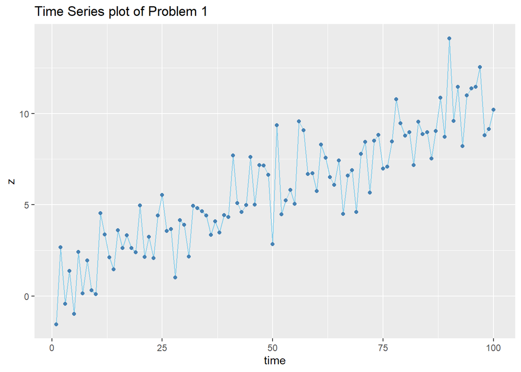

```r
ggplot(data1, aes(t, z)) +
  geom_line(col='skyblue') + geom_point(col='steelblue') +
  xlab("time") + ylab("z") + ggtitle("Time Series plot of Problem 1")
```

그림을 살펴보면 우선 시계열 자료가 시간이 경과함에 따라 1차 추세를 보이고 있는 것으로 판단된다. 이에 따라 1차 추세모형을 적합해보도록 한다.

```r
m1 <- lm(z~t, data=data1)
summary(m1)
```

```
##
## Call:
## lm(formula = z ~ t, data = data1)
##
## Residuals:
##     Min      1Q  Median      3Q     Max
## -3.0803 -1.0287  0.0169  0.8426  4.3288
##
## Coefficients:
##             Estimate Std. Error t value Pr(>|t|)
## (Intercept) 0.818932   0.296301   2.764  0.00682 **
## t           0.099619   0.005094  19.557  < 2e-16 ***
## ---
## Signif. codes:  0 '***' 0.001 '**' 0.01 '*' 0.05 '.' 0.1 ' ' 1
##
## Residual standard error: 1.47 on 98 degrees of freedom
## Multiple R-squared:  0.796,  Adjusted R-squared:  0.7939
## F-statistic: 382.5 on 1 and 98 DF,  p-value: < 2.2e-16
```

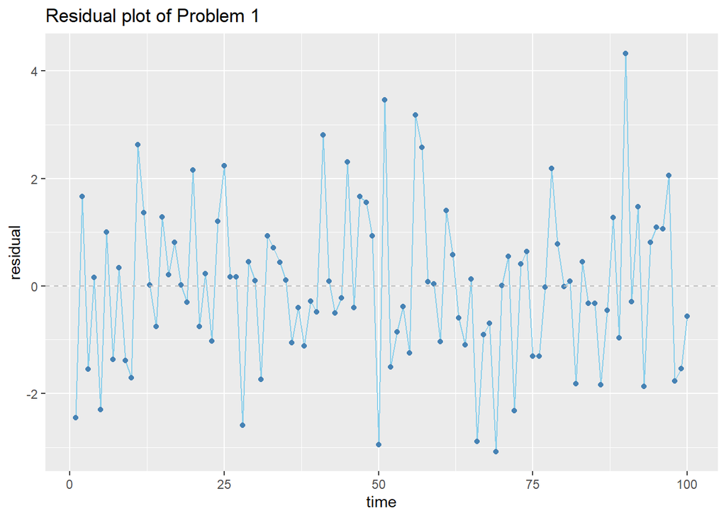

```r
data1$res <- resid(m1)
ggplot(data1, aes(t,res)) + geom_line(col='skyblue') +
  geom_point(col='steelblue')+
  xlab("time")+ylab("residual")+ggtitle("Residual plot of Problem 1")+
  geom_hline(yintercept=0, col='grey', lty=2)
```

잔차 그래프를 보면 잔차가 등분산성은 어느정도 만족하지만 시간에 따라 잔차의 값이 양수와 음수를 왔다갔다 하고 있음을 알 수 있다. 그러므로 잔차가 음의 상관관계가 있다고 여겨지며 이를 확인하기 위해 Durbin-Watson test를 실시해보도록 한다.

```r
dwtest(m1,alternative="less")
```

```
##
##  Durbin-Watson test
##
## data:  m1
## DW = 2.2164, p-value = 0.1611
## alternative hypothesis: true autocorrelation is less than 0
```

분석결과 유의확률의 값이 $p-value=0.1611$로서 유의수준 $0.05$보다 매우 큰 값이다. 따라서 잔차가 음의 상관관계를 가지고 있다고 보기는 어렵다.

```r
dwtest(m1,alternative="two.sided")
```

```
##
##  Durbin-Watson test
##
## data:  m1
## DW = 2.2164, p-value = 0.3221
## alternative hypothesis: true autocorrelation is not 0
```

마찬가지로 가설을 양측으로 바꾸어 검정해도 유의확률의 값이 굉장히 크기 때문에 잔차가 상관관계를 가지고 있다고 보기는 어렵다.

- 2. 1)에서 적합한 추세모형에서 1~10 시차 후의 예측값을 구하여라.

```r
newdata <- data.frame(t=101:110)
predict(m1,newdata)
```

```
##        1        2        3        4        5        6        7        8
## 10.88044 10.98006 11.07968 11.17930 11.27892 11.37854 11.47816 11.57777
##        9       10
## 11.67739 11.77701
```

- 3. 적절한 평활법을 적용한 후 잔차분석을 하여라.

```r
library(forecast)
```

```r
library(data.table)
library(ggplot2)
library(lmtest)
library(TTR)
```

1)을 통해 시계열 자료가 1차 추세가 있다고 판단하였으므로 Holt-Winters의 단순지수평활법을 적용해보도록 한다. 먼저 다음과 같이 시계열 자료를 다시 만든다.

```r
series1 <- ts(data1$z,start=c(1))
series1
```

```
## Time Series:
## Start = 1
## End = 100
## Frequency = 1
##   [1] -1.5346871  2.6850469 -0.4288189  1.3724199 -0.9800884  2.4156505
##   [7]  0.1460579  1.9565546  0.3314012  0.1031952  4.5465702  3.3733991
##  [13]  2.1320092  1.4610979  3.5995999  2.6229617  3.3260846  2.6279068
##  [19]  2.4061911  4.9681833  2.1537724  3.2376604  2.0848844  4.4146009
##  [25]  5.5427871  3.5727733  3.6793795  1.0197987  4.1619256  3.9038326
##  [31]  2.1724542  4.9360919  4.8127781  4.6404884  4.4090738  3.3529045
##  [37]  4.0967541  3.4881527  4.4249974  4.3210561  7.7103219  5.0907609
##  [43]  4.5999605  4.9773808  7.6107690  4.9986647  7.1678722  7.1542270
##  [49]  6.6329637  2.8462231  9.3646617  4.4855729  5.2444451  5.8160173
##  [55]  5.0466196  9.5742821  9.0751720  6.6775546  6.7345322  5.7569890
##  [61]  8.3008035  7.5701959  6.5050066  6.0962461  7.4245090  4.4973441
##  [67]  6.5920516  6.9026479  4.6123368  7.7952478  8.4416974  5.6684225
##  [73]  8.5028659  8.8312543  6.9776594  7.0775957  8.4638087 10.7761422
##  [79]  9.4661818  8.7774843  8.9804188  7.1654550  9.5367387  8.8641697
##  [85]  8.9645710  7.5418683  9.0336999 10.8611356  8.7190544 14.1133979
##  [91]  9.5868440 11.4598053  8.2142746 10.9960972 11.3776375 11.4480245
##  [97] 12.5356509  8.8132146  9.1437447 10.2114895
```

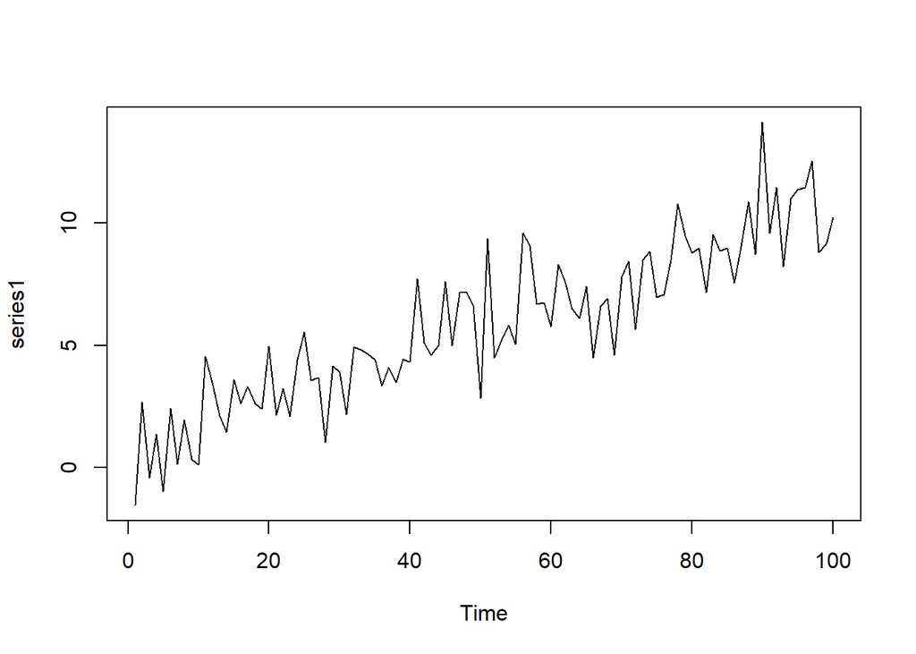

```r
plot.ts(series1)
```

이에 대하여 Holt-Winters 단순지수평활법을 적용하면 다음과 같다.

```r
seriesforecasts <- HoltWinters(series1, beta=FALSE, gamma=FALSE)
seriesforecasts
```

```
## Holt-Winters exponential smoothing without trend and without seasonal component.
##
## Call:
## HoltWinters(x = series1, beta = FALSE, gamma = FALSE)
##
## Smoothing parameters:
##  alpha: 0.2656872
##  beta : FALSE
##  gamma: FALSE
##
## Coefficients:
##       [,1]
## a 10.20772
```

적용결과 평활모수는 $\alpha=0.267$로 추정되었다. 이와 관련한 그래프는 다음과 같이 그릴 수 있다.

```r
head(seriesforecasts$fitted)
```

```
## Time Series:
## Start = 2
## End = 7
## Frequency = 1
##          xhat       level
## 2 -1.53468707 -1.53468707
## 3 -0.41355767 -0.41355767
## 4 -0.41761237 -0.41761237
## 5  0.05797635  0.05797635
## 6 -0.21782419 -0.21782419
## 7  0.48185640  0.48185640
```

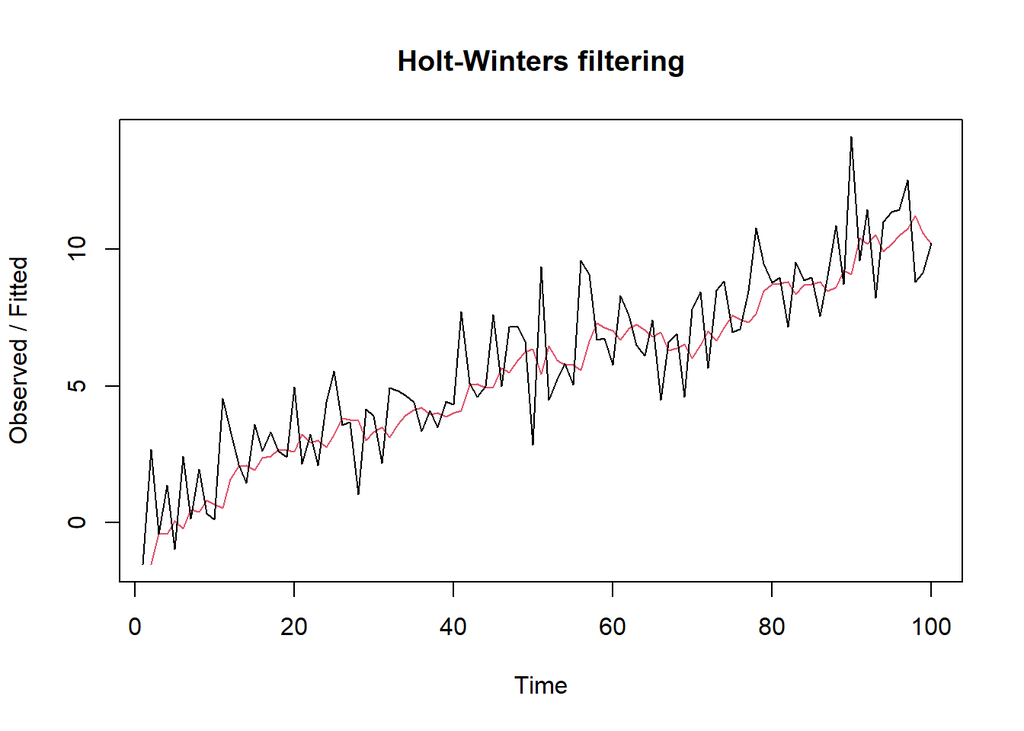

```r
plot(seriesforecasts)
```

이제 잔차분석을 하기 위해 다음과 같이 잔차를 생성하고 그래프를 그려보도록 한다.

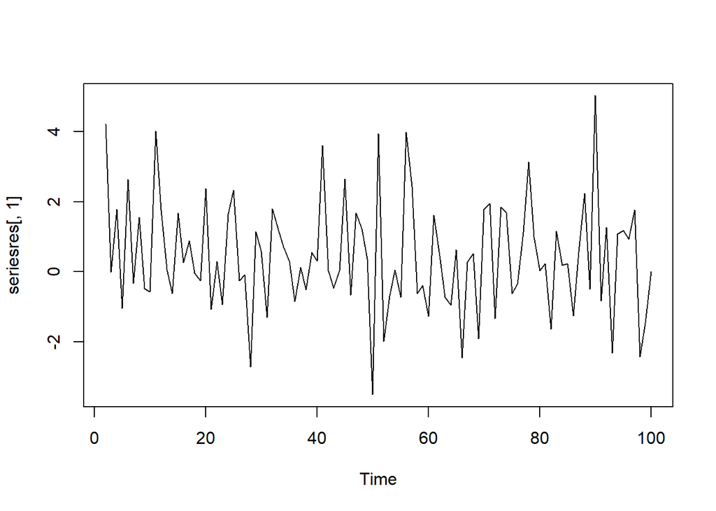

```r
seriesres <- series1-seriesforecasts$fitted
plot(seriesres[,1])
```

위의 그래프를 통해 잔차의 패턴이 1차 추세모형을 적합했을 경우와 비슷한 형태임을 확인할 수 있다. 따라서 잔차가 등분산성, 독립성을 어느정도 만족한다고 판단된다.

- 4. 3)의 결과를 이용하여 1~10시차 후의 예측값을 구하여라.

```r
seriesforecasts2 <- forecast(seriesforecasts, h=10)
seriesforecasts2
```

```
##     Point Forecast    Lo 80    Hi 80    Lo 95    Hi 95
## 101       10.20772 8.149936 12.26550 7.060610 13.35483
## 102       10.20772 8.078545 12.33690 6.951428 13.46401
## 103       10.20772 8.009471 12.40597 6.845789 13.56965
## 104       10.20772 7.942503 12.47294 6.743370 13.67207
## 105       10.20772 7.877459 12.53798 6.643893 13.77155
## 106       10.20772 7.814181 12.60126 6.547118 13.86832
## 107       10.20772 7.752534 12.66291 6.452837 13.96260
## 108       10.20772 7.692397 12.72304 6.360865 14.05457
## 109       10.20772 7.633665 12.78178 6.271042 14.14440
## 110       10.20772 7.576243 12.83920 6.183223 14.23222
```

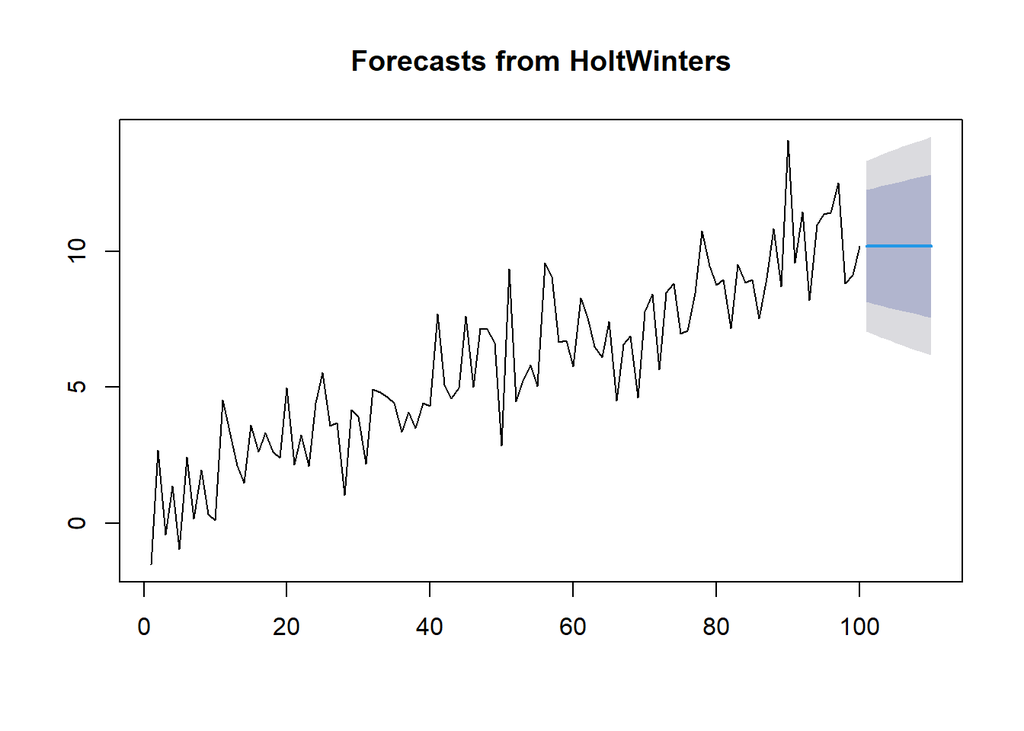

```r
plot(seriesforecasts2)
```

- 5. 실제 1~10차 후의 관측값이 ’data1_new.csv’일 때, 2), 4)의 결과를 이용하여 어느 모형이 더 적합했는지에 대해 비교하여라.

```r
newdata1 <- read.csv("C:/Users/HSY/Desktop/data1_new.csv",sep=",",header=T)
newdata1 <- newdata1[,c(2:3)]
newdata1
```

```
##      t         z
## 1  101 11.577471
## 2  102 13.171004
## 3  103 12.730258
## 4  104 12.242375
## 5  105 10.877077
## 6  106 13.297355
## 7  107 14.632224
## 8  108 15.049088
## 9  109  9.671734
## 10 110 12.216420
```

모형의 예측정확도를 비교하기 위해 다음과 같이 RMSE를 계산해보도록 한다. $RMSE=\sqrt{\sum_{t=101}^{110} (z_{t} - {\hat{z_{t}}})^{2}}$

```r
z_new <- newdata1$z
# 1차 추세모형
newdata <- data.frame(t=101:110)
zhat1 <- predict(m1,newdata)
RMSE1 <- sqrt(sum((z_new-zhat1)^2))
RMSE1
```

```
## [1] 6.260822
```

```r
# 단순지수평활법
zhat2 <- seriesforecasts2$mean
RMSE2 <- sqrt(sum((z_new-zhat2)^2))
RMSE2
```

```
## [1] 8.859538
```

결과적으로 1차 추세모형에 대한 RMSE의 값이 더 작기 때문에 1차 추세모형이 단순지수평활법에 비해 더 예측을 잘했다고 판단할 수 있다.

2. ’usapass.txt’는 미국 월별 비행기 승객 수(단위 : 천 명)의 시계열자료이다. log 변환 후 아래의 분석을 수행하시오.
- 1. 왜 log 변환이 필요한지에 대해 간단히 설명하여라.

```r
usapass <- scan("C:/Users/HSY/Desktop/usapass.txt")
usapass <- ts(usapass,start=c(1))
usapass
```

```
## Time Series:
## Start = 1
## End = 144
## Frequency = 1
##   [1] 112 118 132 129 121 135 148 148 136 119 104 118 115 126 141 135 125 149
##  [19] 170 170 158 133 114 140 145 150 178 163 172 178 199 199 184 162 146 166
##  [37] 171 180 193 181 183 218 230 242 209 191 172 194 196 196 236 235 229 243
##  [55] 264 272 237 211 180 201 204 188 235 227 234 264 302 293 258 229 203 229
##  [73] 242 233 267 269 270 315 364 347 312 274 237 278 284 277 317 313 318 374
##  [91] 413 405 355 306 271 306 315 301 362 348 363 435 491 505 404 359 310 337
## [109] 340 318 362 348 363 435 491 505 404 359 310 337 360 342 406 396 420 472
## [127] 548 559 463 407 362 405 417 391 419 461 472 535 622 606 508 461 390 432
```

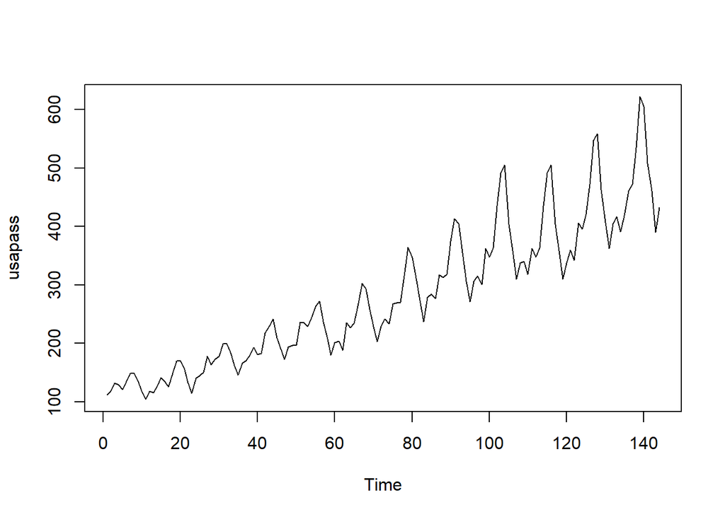

```r
plot.ts(usapass)
```

위의 시계열 그래프를 통해서 볼 때 본 시계열 자료는 시간이 지날수록 증가하는 추세가 있고 변동성이 커지는 경향이 있으며 계절적인 주기성도 보이고 있다. 따라서 log변환을 통해 자료를 보완하는 것이 필요하다고 여겨진다. 이에 따라 다음과 같이 log변환을 실시하도록 한다.

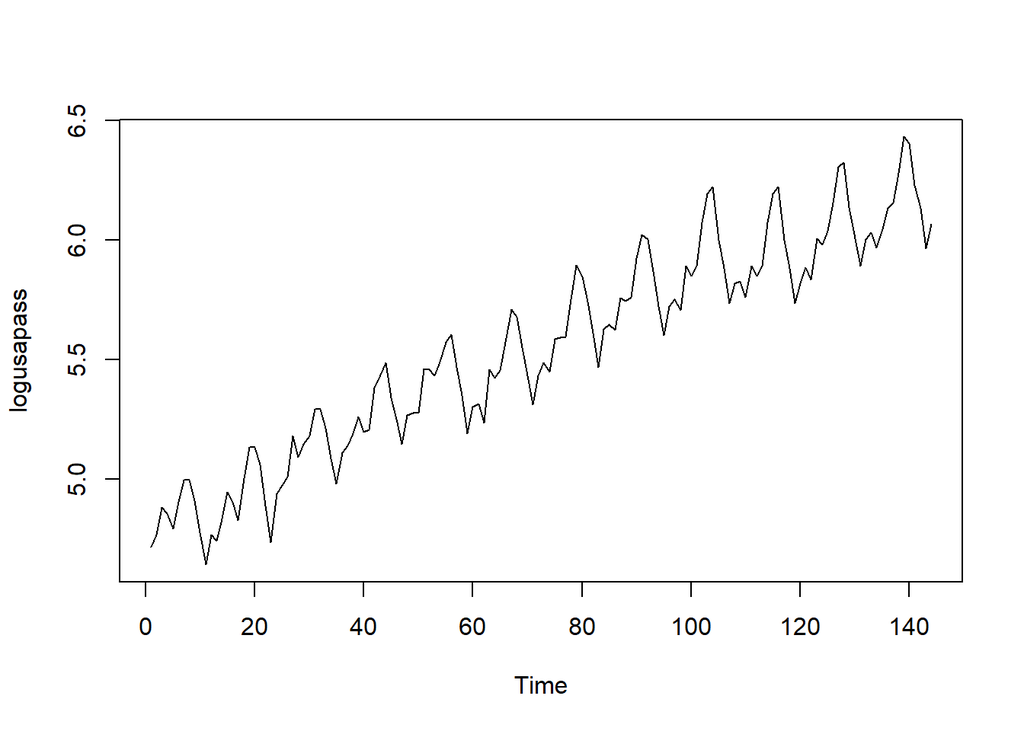

```r
logusapass <- log(usapass)
plot.ts(logusapass)
```

log변환을 실시한 결과 변동성이 어느정도 보완되었다고 볼 수 있다.

- 2. 적절한 추세모형 적합 후 잔차분석을 하여라.

1)을 통해 살펴본 log변환 이후의 시계열 자료의 그래프를 통해 추세의 형태가 전체적으로는 증가하지만 시간이 지날수록 약간씩 증가율이 줄어든다고 보여진다. 이에 따라 2차 추세모형을 적합해보도록 한다.

```r
t <- 1:length(logusapass)
t2 <- t^2
data2 <- data.frame(t=t,logusapass=logusapass)
m2 <- lm(logusapass~t+t2,data=data2)
summary(m2)
```

```
##
## Call:
## lm(formula = logusapass ~ t + t2, data = data2)
##
## Residuals:
##      Min       1Q   Median       3Q      Max
## -0.29253 -0.09097 -0.02178  0.09452  0.34659
##
## Coefficients:
##               Estimate Std. Error t value Pr(>|t|)
## (Intercept)  4.734e+00  3.487e-02 135.738  < 2e-16 ***
## t            1.334e-02  1.110e-03  12.010  < 2e-16 ***
## t2          -2.246e-05  7.418e-06  -3.027  0.00293 **
## ---
## Signif. codes:  0 '***' 0.001 '**' 0.01 '*' 0.05 '.' 0.1 ' ' 1
##
## Residual standard error: 0.1376 on 141 degrees of freedom
## Multiple R-squared:  0.9051, Adjusted R-squared:  0.9038
## F-statistic: 672.6 on 2 and 141 DF,  p-value: < 2.2e-16
```

적합결과 수정된 결정계수의 값이 $R_{adj}^2=0.9038$ 로 굉장히 높게 나왔기 때문에 적절하게 추세모형을 적합한 것으로 보여지며, 이에 대한 잔차도를 그려보면 다음과 같다.

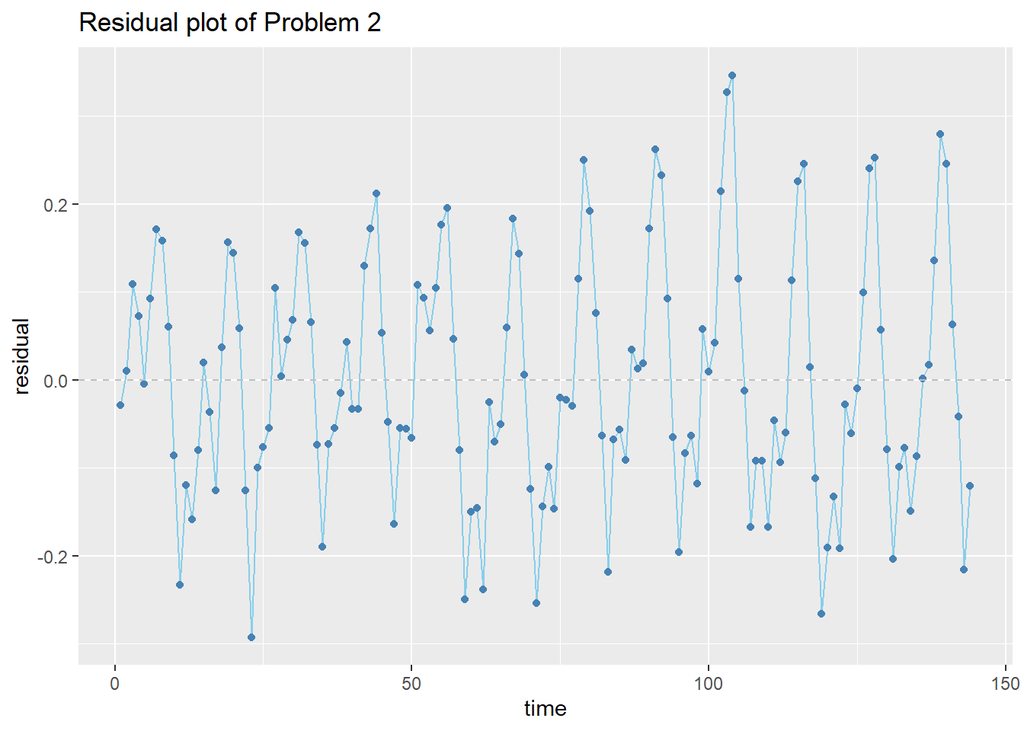

```r
data2$res <- resid(m2)
ggplot(data2, aes(t,res)) + geom_line(col='skyblue') +
  geom_point(col='steelblue')+
  xlab("time")+ylab("residual")+ggtitle("Residual plot of Problem 2")+
  geom_hline(yintercept=0, col='grey', lty=2)
```

잔차도를 보면 잔차가 시간에 따라 주기적으로 양수와 음수를 왔다갔다하는 움직임을 보이고 있다. 이에 따라 잔차에 양의 상관관계가 있다고 판단할 수 있으며 이에 대한 Durbin-Watson test 결과는 다음과 같다.

```r
dwtest(m2,alternative="greater")
```

```
##
##  Durbin-Watson test
##
## data:  m2
## DW = 0.61841, p-value < 2.2e-16
## alternative hypothesis: true autocorrelation is greater than 0
```

결과적으로 유의확률이 굉장히 작게 나오기 때문에 잔차에 양의 상관관계가 있다고 판단할 수 있다.

- 3. 적절한 평활법을 적용한 후 잔차분석을 하여라.

본 시계열 자료는 추세, 계절성을 모두 가지고 있고 시간에 따른 변동성도 있기 때문에 Holt-Winters의 계절지수평활법 중 승법계절모형을 적합해보도록 한다.

```r
usapass <- ts(usapass,start=c(1),frequency=12)
logusapass <- log(usapass)
fit2 <- HoltWinters(logusapass, seasonal="multiplicative")
fit2
```

```
## Holt-Winters exponential smoothing with trend and multiplicative seasonal component.
##
## Call:
## HoltWinters(x = logusapass, seasonal = "multiplicative")
##
## Smoothing parameters:
##  alpha: 0.3448848
##  beta : 0.003816674
##  gamma: 0.7802074
##
## Coefficients:
##            [,1]
## a   6.167526164
## b   0.008779793
## s1  0.987550850
## s2  0.976253992
## s3  0.994335242
## s4  1.002007555
## s5  1.005547761
## s6  1.026551647
## s7  1.050162767
## s8  1.048163498
## s9  1.016734654
## s10 0.996390519
## s11 0.968939958
## s12 0.983870338
```

적합결과 최적의 평활모수는 $\alpha=0.3449, \beta=0.0038, \gamma=0.7802$로 추정되었다. 이에 대한 잔차도는 다음과 같이 그릴 수 있다.

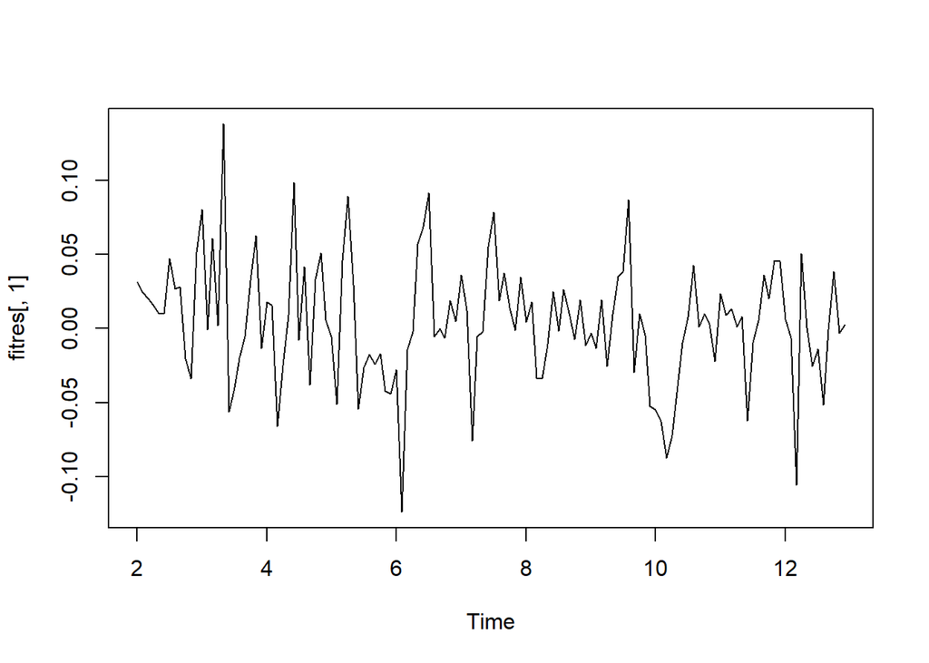

```r
fitres <- logusapass-fit2$fitted
plot(fitres[,1])
```

잔차도를 통해 살펴봤을 때 잔차에 대한 등분산성, 독립성 등이 어느정도 만족된다고 보여진다.

- 4. 적절한 분해법에 의해 각 성분을 분해해여 시계열 그림을 그려라.

본 시계열을 이동평균을 이용하여 다음과 같이 분해할 수 있다.

```r
library(forecast)
library(TTR)
library(lmtest)
stl_fit2 <- stl(logusapass, s.window=12)
stl_fit2$time.series[1:10,]
```

```
##            seasonal    trend    remainder
##  [1,] -0.0908934374 4.816290 -0.006897330
##  [2,] -0.0841946511 4.819998  0.034881565
##  [3,]  0.0482262974 4.823706  0.010869844
##  [4,]  0.0009225527 4.827414  0.031475999
##  [5,] -0.0168433127 4.831614 -0.018980270
##  [6,]  0.0958679056 4.835814 -0.026407531
##  [7,]  0.1911956986 4.840015 -0.033998104
##  [8,]  0.1848800116 4.844144 -0.031811770
##  [9,]  0.0617000441 4.848273  0.002681458
## [10,] -0.0766029228 4.852403  0.003323680
```

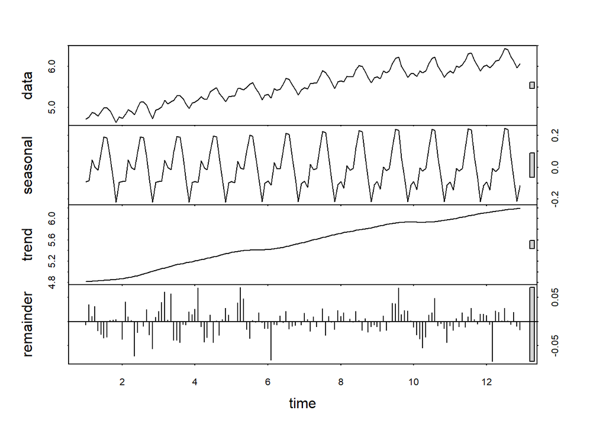

```r
plot(stl_fit2)
```

- 5. 4)에서 추정된 불규칙성분을 통해 적용된 분해법이 적절했는지 논하여라.

4)의 그래프에서 remainder에 해당하는 부분이 추세와 계절성을 제외한 불규칙성분과 관련한 결과이다. 결과적으로 불규칙성분의 절대값이 대부분 0.05 이하로 굉장히 작기 때문에 전체적으로 분해법이 적절하게 적용되었다고 판단된다.

3. 확률과정 $Z_{t}=1+0.9Z_{t-1}+\epsilon_{t}$, $t=1,2,\dots,100$으로부터의 시계열 자료를 생성한 후 다음을 수행하라.
- 1. {$Z_{t}$}의 시계열그림을 그려라.

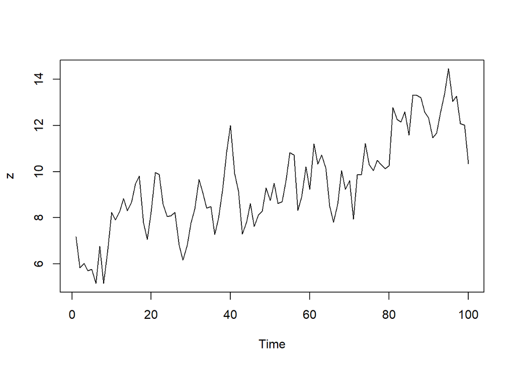

```r
library(data.table)
library(ggplot2)
library(forecast)
library(gridExtra)
sim_ar <- function(n, mu, phi){
  ### n : sample size
  ### mu : mean
  ### phi : p-dim coefficients
  p <- length(phi)
  z <- rnorm(n+100)  #epsilon ~ WN(0, sigma^2), iid N(0,1)
  # delta <- (1-sum(phi))*mu
  delta <- 1
  for (k in (length(phi)+1):(n+100)){
    z[k] <- delta + sum(z[(k-1):(k-p)]*phi) + rnorm(1)
  }
  return(z[-(1:100)])
}
z <- sim_ar(100, 0, 0.9)
plot.ts(z)
```

- 2. SACF $\hat{\rho_{k}}$, $k=0,1,2,\dots,10$을 구하여 표본상관도표를 그려라.

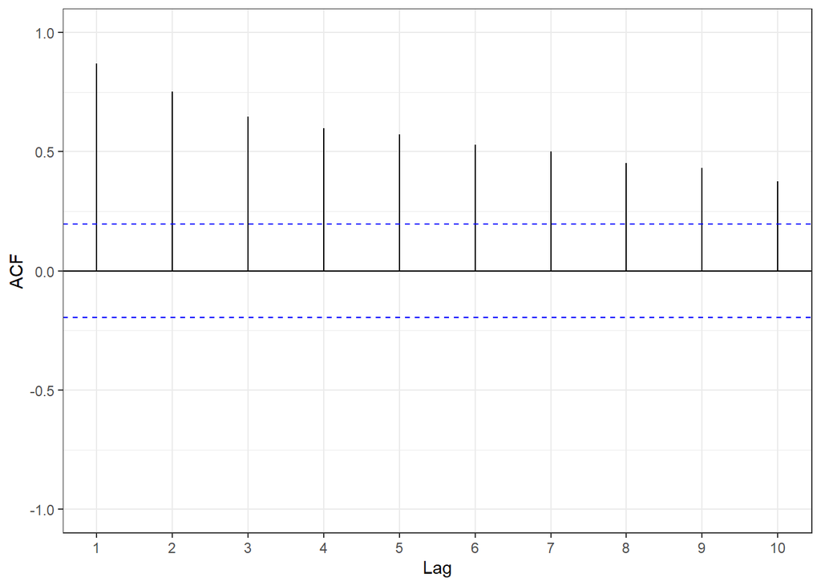

```r
ggAcf(z, lag.max=10) +
  theme_bw() + ylim(-1,1) +
  theme(plot.title = element_blank())
```

SACF의 값이 지수적으로 감소하고 있다. (AR모형의 특징)

- 3. SPACF $\hat{\phi_{kk}}$, $k=0,1,2,\dots,10$를 구하여 표본부분상관도표를 그려라.

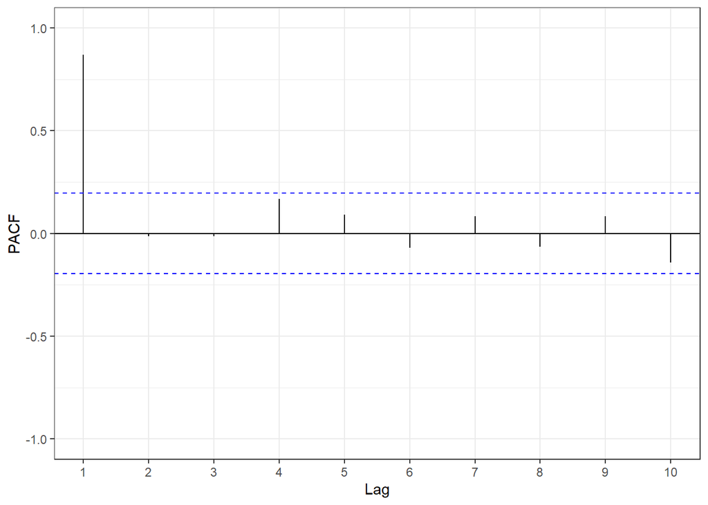

```r
ggPacf(z, lag.max=10) +
  theme_bw() + ylim(-1,1) +
  theme(plot.title = element_blank())
```

SPACF의 값이 시차 1에서만 유의하고 그 이후에는 절단되어 있다. (AR(1)모형의 특징)

- 4. $(Z_{t},Z_{t-1})$의 산점도를 그리고, 이 산점도와 $\hat{\rho_{1}}$의 관계를 설명하여라.

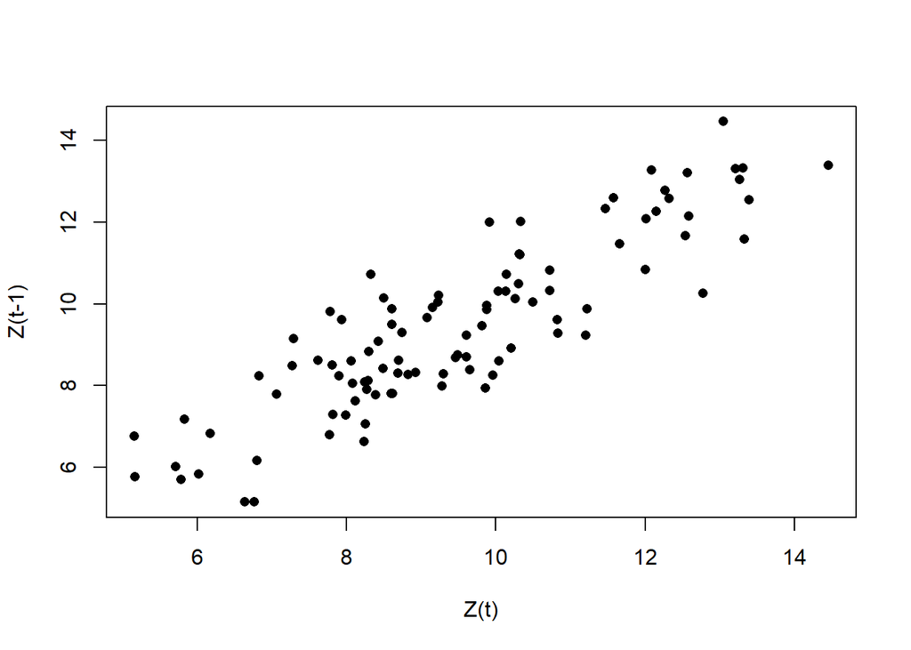

```r
plot(z[-1],z[-length(z)], pch=16,
     xlab="Z(t)", ylab='Z(t-1)')
```

산점도를 보면 $Z_{t}$와 $Z_{t-1}$ 사이에 강한 양의 상관관계가 있음을 알 수 있다. 즉, $\hat{\rho_{1}}$의 값은 $Z_{t}$와 $Z_{t-1}$ 사이의 상관관계와 연관성이 있다.

- 5. $(Z_{t},Z_{t-2})$의 산점도를 그리고, 이 산점도와 $\hat{\rho_{2}}$의 관계를 설명하여라.

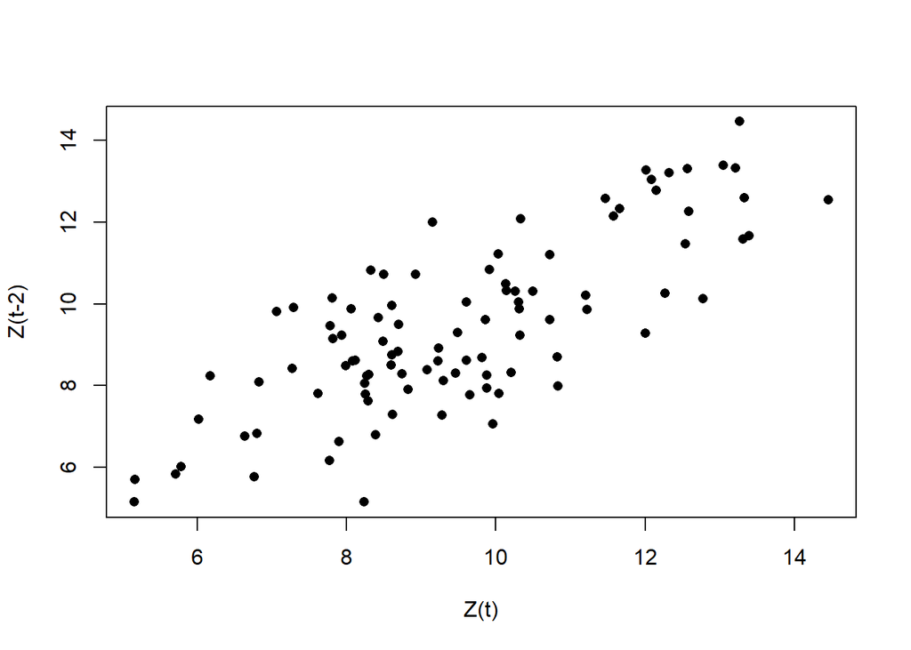

```r
plot(z[-c(1,2)],z[-c(length(z)-1,length(z))], pch=16,
     xlab="Z(t)", ylab='Z(t-2)')
```

4)의 결과와 같은 맥락으로 해석할 수 있다. 즉, $\hat{\rho_{2}}$의 값은 $Z_{t}$와 $Z_{t-2}$ 사이의 상관관계와 연관성이 있다.

4. $\epsilon_{t} \sim i.i.d N(0,1^2)$ 을 따를 때, 다음의 확률 과정을 따르는 표본의 크기가 100인 시계열을 생성한 후, 각 모의실험 자료에 대하여 다음에 답하여라. 단 AR 혹은 ARMA 과정에서 AR 부분의 차수가 p인 경우 필요한 초기값은 해당하는 확률과정의 평균 $\mu$로 놓기로 하자.

model 1 : $Z_{t}=\epsilon_{t}+0.7\epsilon_{t-1}$ model 2 : $Z_{t}−0.8Z_{t-1}=\epsilon_{t}$ model 3 : $Z_{t}−0.5Z_{t-1}=\epsilon_{t}+0.3\epsilon_{t-1}$

- 1. {$Z_{t}$}의 시계열그림을 그려라.
- 2. SACF $\hat{\rho_{k}}$와 SPACF $\hat{\phi_{kk}}$ ($k=0,1,2,\dots,10$) 의 상관도표를 그려라.
- 3. 2)의 상관도표가 각 확률과정에 대한 ACF, PACF의 이론적인 형태와 비슷한지 논하라.

1)과 2), 그리고 3)에 대한 결과를 동시에 보이도록 하겠다.

model 1 : $Z_{t}=\epsilon_{t}+0.7\epsilon_{t-1}$ : MA(1)

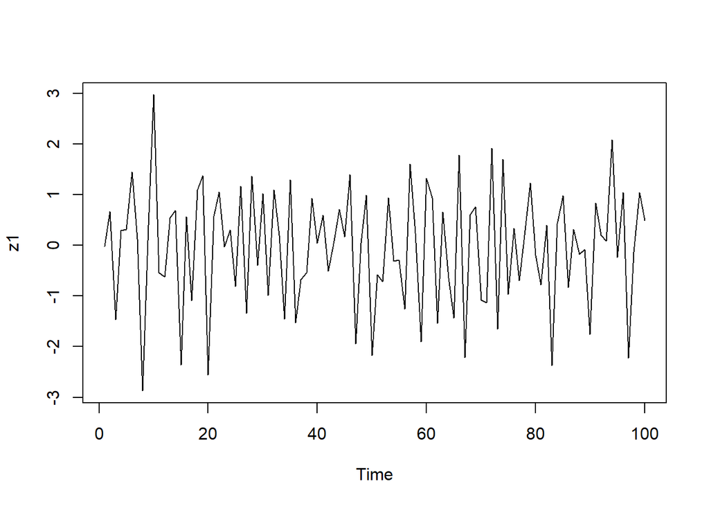

```r
z1 <- arima.sim(n=100,list(order=c(0,0,1),ma=-0.7))
ts.plot(z1)
```

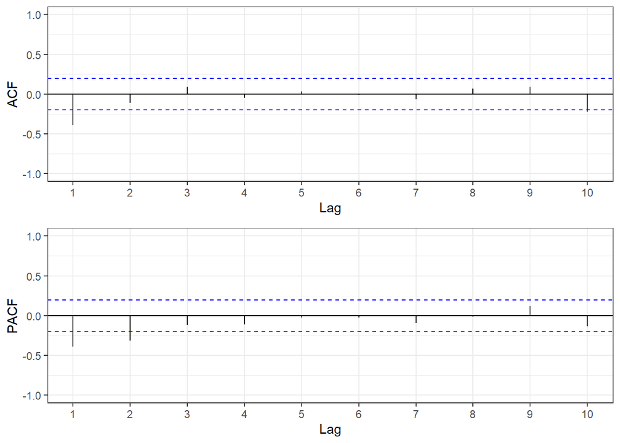

```r
p1 <- ggAcf(z1, lag.max=10) +
  theme_bw() + ylim(-1,1) +
  theme(plot.title = element_blank())
p2 <- ggPacf(z1, lag.max=10) +
  theme_bw() +ylim(-1,1) +
  theme(plot.title = element_blank())
grid.arrange(p1, p2, nrow = 2)
```

model 2 : $Z_{t}−0.8Z_{t-1}=\epsilon_{t}$ : AR(1)

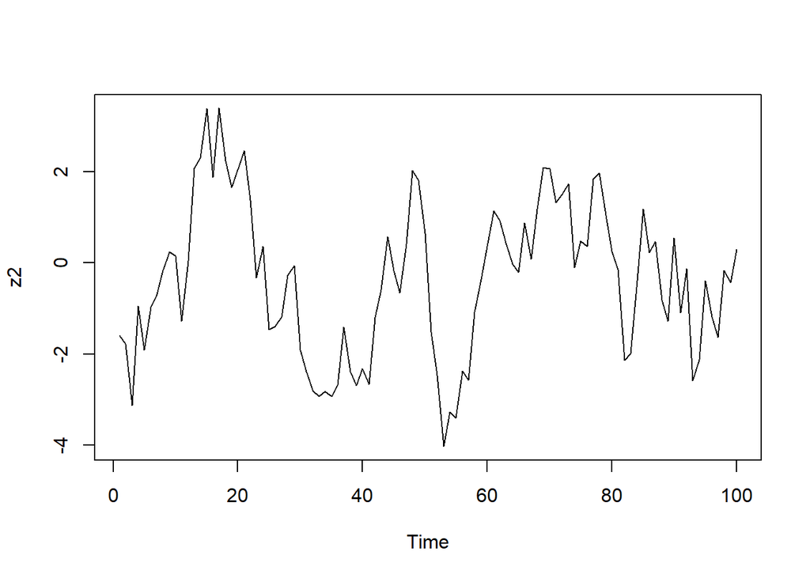

```r
z2 <- arima.sim(n=100,list(order=c(1,0,0),ar=0.8))
ts.plot(z2)
```

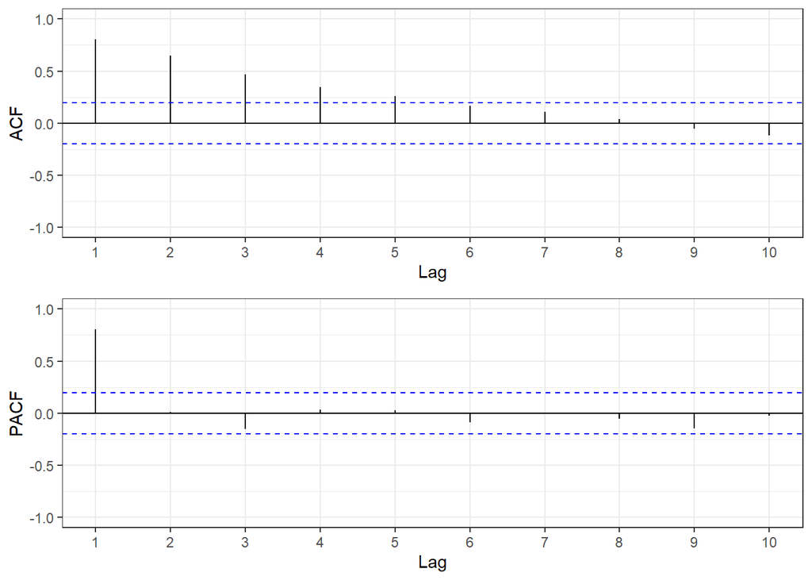

```r
p1 <- ggAcf(z2, lag.max=10) +
  theme_bw() + ylim(-1,1) +
  theme(plot.title = element_blank())
p2 <- ggPacf(z2, lag.max=10) +
  theme_bw() +ylim(-1,1) +
  theme(plot.title = element_blank())
grid.arrange(p1, p2, nrow = 2)
```

ACF는 지수적으로 감소하는, 그리고 PACF는 시차 1만 살아남고 나머지는 절단되는 AR(1)모형의 이론적인 ACF와 PACF의 특징을 나타내고 있다.

model 3 : $Z_{t}−0.5Z_{t-1}=\epsilon_{t}+0.3\epsilon_{t-1}$ : ARMA(1,1)

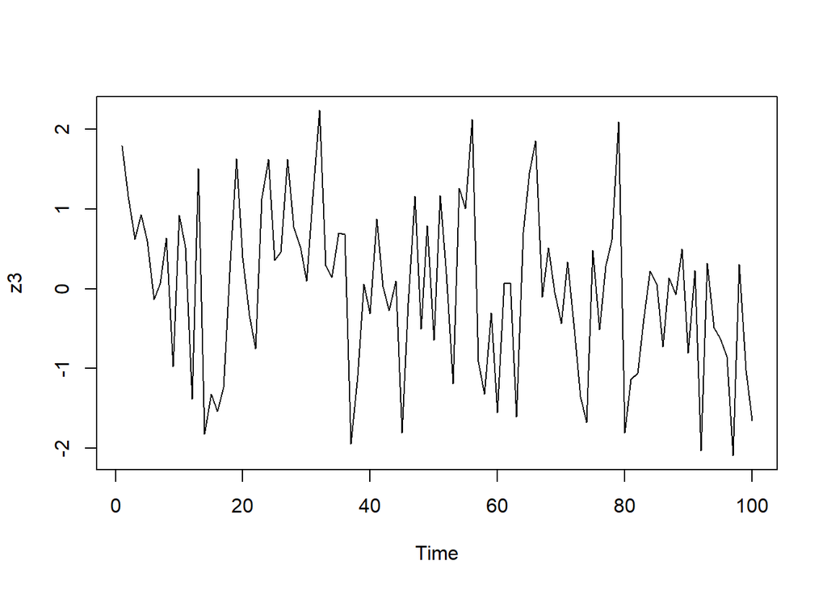

```r
z3 <- arima.sim(n=100,list(order=c(1,0,1),ar=0.5,ma=-0.3))
ts.plot(z3)
```

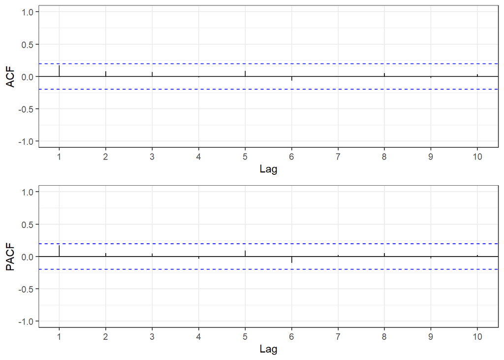

```r
p1 <- ggAcf(z3, lag.max=10) +
  theme_bw() + ylim(-1,1) +
  theme(plot.title = element_blank())
p2 <- ggPacf(z3, lag.max=10) +
  theme_bw() +ylim(-1,1) +
  theme(plot.title = element_blank())
grid.arrange(p1, p2, nrow = 2)
```

- 4. 또한 표본의 크기를 증가시켜 모의실험을 한 후 3)의 결과 및 이론적인 형태와 비교하여라.

model 1 : $Z_{t}=\epsilon_{t}+0.7\epsilon_{t-1}$ : MA(1)

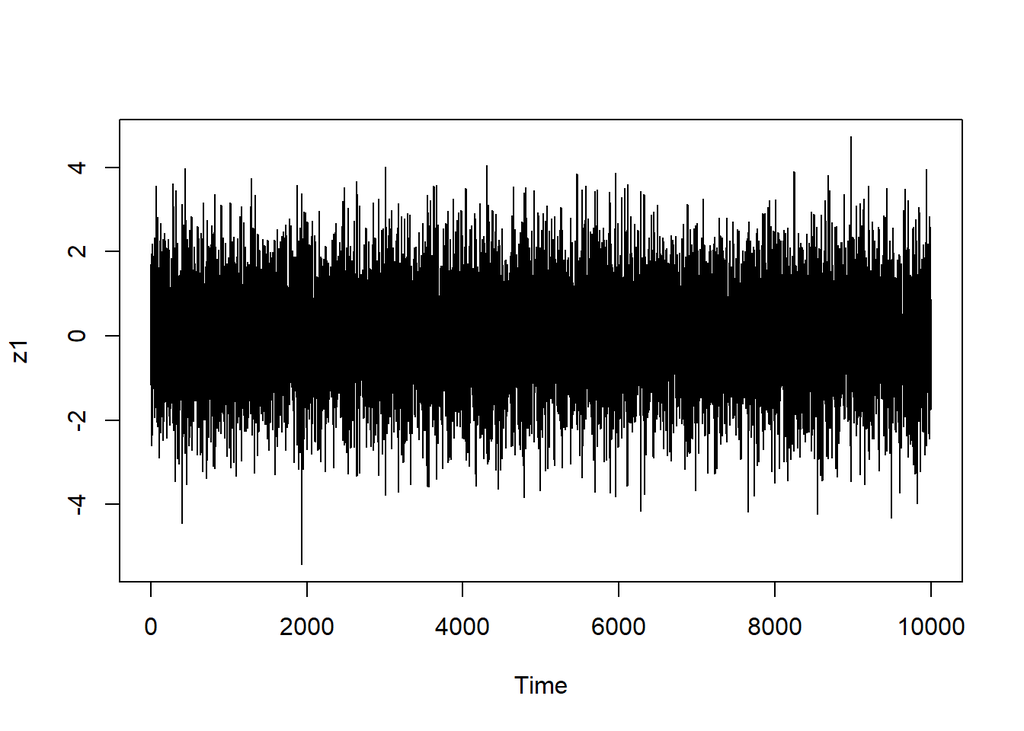

```r
z1 <- arima.sim(n=10000,list(order=c(0,0,1),ma=-0.7))
ts.plot(z1)
```

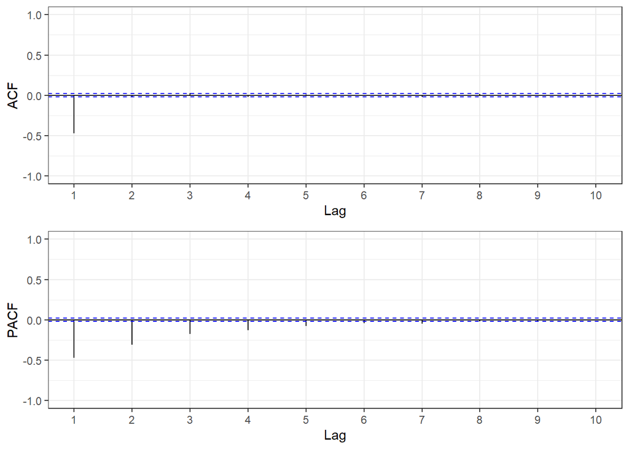

```r
p1 <- ggAcf(z1, lag.max=10) +
  theme_bw() + ylim(-1,1) +
  theme(plot.title = element_blank())
p2 <- ggPacf(z1, lag.max=10) +
  theme_bw() +ylim(-1,1) +
  theme(plot.title = element_blank())
grid.arrange(p1, p2, nrow = 2)
```

model 2 : $Z_{t}−0.8Z_{t-1}=\epsilon_{t}$ : AR(1)

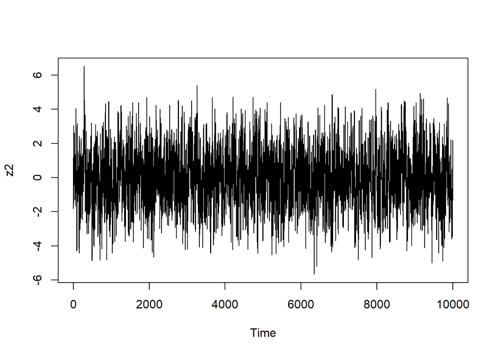

```r
z2 <- arima.sim(n=10000,list(order=c(1,0,0),ar=0.8))
ts.plot(z2)
```

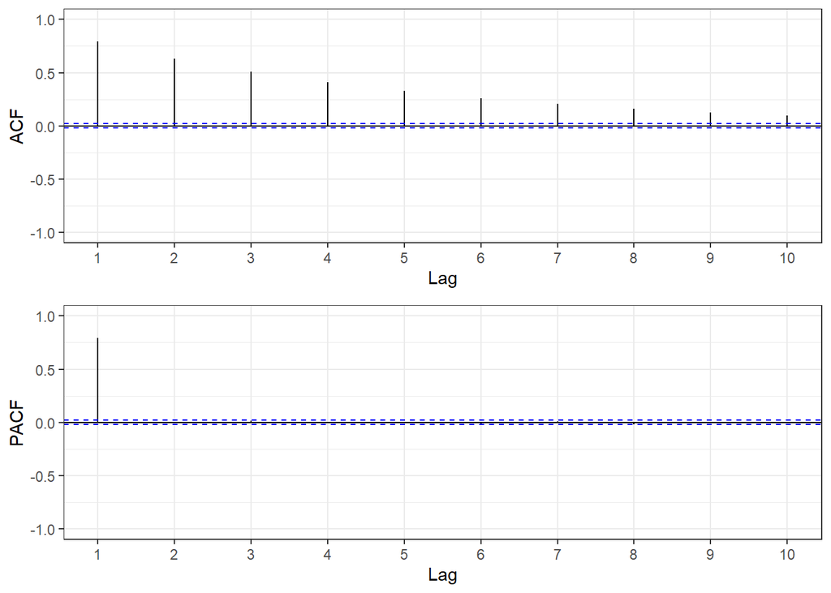

```r
p1 <- ggAcf(z2, lag.max=10) +
  theme_bw() + ylim(-1,1) +
  theme(plot.title = element_blank())
p2 <- ggPacf(z2, lag.max=10) +
  theme_bw() +ylim(-1,1) +
  theme(plot.title = element_blank())
grid.arrange(p1, p2, nrow = 2)
```

model 3 : $Z_{t}−0.5Z_{t-1}=\epsilon_{t}+0.3\epsilon_{t-1}$ : ARMA(1,1)

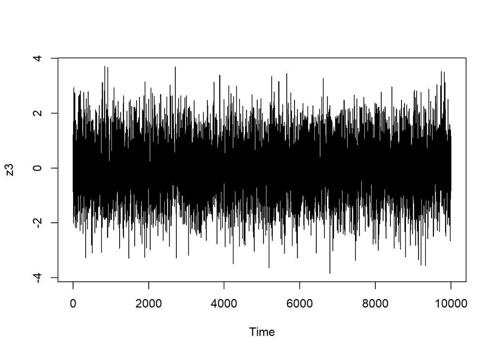

```r
z3 <- arima.sim(n=10000,list(order=c(1,0,1),ar=0.5,ma=-0.3))
ts.plot(z3)
```

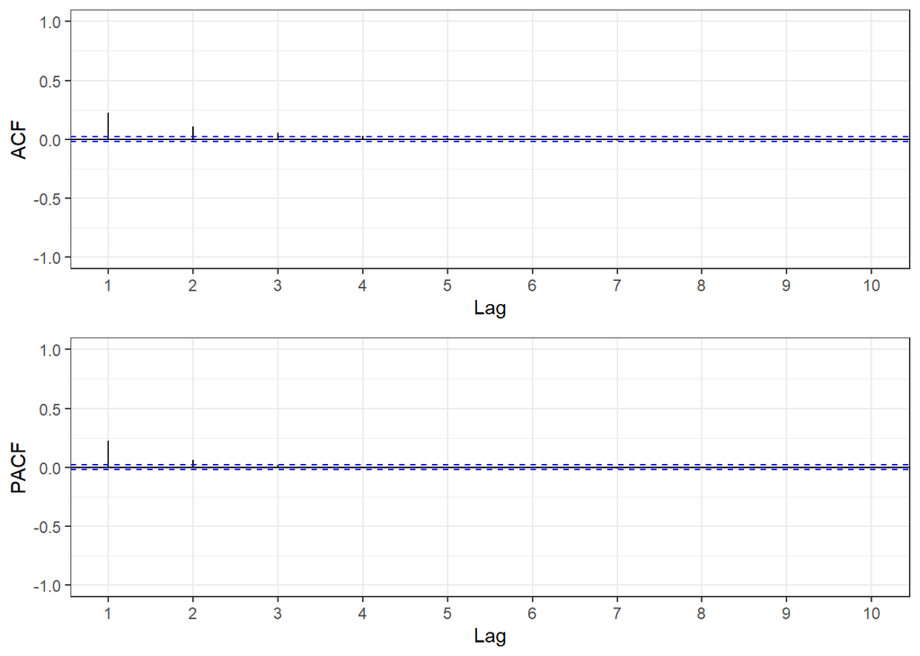

```r
p1 <- ggAcf(z3, lag.max=10) +
  theme_bw() + ylim(-1,1) +
  theme(plot.title = element_blank())
p2 <- ggPacf(z3, lag.max=10) +
  theme_bw() +ylim(-1,1) +
  theme(plot.title = element_blank())
grid.arrange(p1, p2, nrow = 2)
```